# Verification of Zhao et al. (2023)

Ian Hussey

```r
library(tidyverse)
library(metafor)
library(readxl)
library(janitor)
library(ggstance)
library(knitr)
library(kableExtra)

heterogeneity_metrics <- function(fit){
  paste0("Heterogeneity: Q(df = ", fit$k - 1, ") = ", janitor::round_half_up(fit$QE, 2),
         ", p ", ifelse(fit$QEp < 0.0001, "< .0001", paste0("= ", as.character(janitor::round_half_up(fit$QEp, 4)))),
         ", tau^2 = ", janitor::round_half_up(fit$tau2, 4),
         ", I^2 = ", janitor::round_half_up(fit$I2, 1),
         "%, H^2 = ", janitor::round_half_up(fit$H2, 2))
}

# function to convert Cohen's d to NNT. NB this approximates Ruscio's A (ie probability of superiority) from cohen's d rather than calculating it directly.
d_to_nnt <- function(d) {
  # Calculate the area under the curve (AUC) using the cumulative distribution function
  auc <- pnorm(d / sqrt(2))

  # Calculate the risk difference (RD)
  rd <- 2 * (auc - 0.5)

  # Calculate the NNT
  nnt <- 1 / abs(rd)

  return(nnt)
}

round_with_zeros <- function(x, digits = 1) {
  sprintf(paste0("%.", digits, "f"), janitor::round_half_up(x, digits))
}
```

# Reproduce Zhao’s results

Zhao et al. (2023) present the results of multiple meta-analyses, sensitivity analyses, and subgroup analyses. Here, I attempt to reproduce and verify the result of only the first meta-analysis reported in the first forest plot (figure 4), which included the largest number of studies and data for the original studies’ post-intervention time point.

Zhao et al. (2023, p. 6) reported “Effect of ACT on depression: Eleven studies reported the effect of ACT on depression levels in 887 patients with depressive disorders. There was statistically significant heterogeneity among the studies (P < 0.00001; I2= 93%), therefore, the random effects model was used to conduct meta-analysis. There was significant treatment effect from ACT in comparison to other treatments, as shown in the forest plot in Fig. 4.”

However, Figure 4 does not present the full meta-analysis, but rather a sensitivity analysis after excluding A-Tjak et al. (2018). The rationale for excluding that study is not stated. I therefore first fit a meta-analysis to all 11 studies, then perform a series of outlier/undue influence tests to try to reproduce the conclusion that A-Tjak et al. (2018) should be excluded, and then finally I fit a new meta-analysis to the remaining 10 studies to try to reproduce the meta-analytic effect reported in Zhao et al. (2023) Figure 4.

Summary stats (M, SD, N for both groups) were extracted from Zhao et al.’s (2023) forest plot in Figure 4. Specifically:

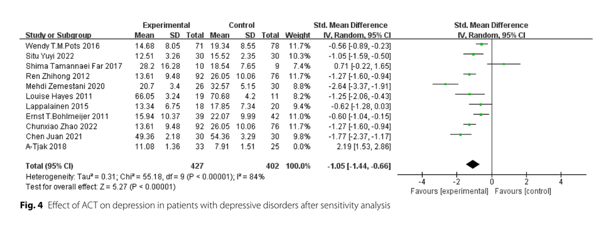

```r
knitr::include_graphics("../../data/screenshots/zhao et al figure 4.png")
```

## Meta-analysis of all 11 studies

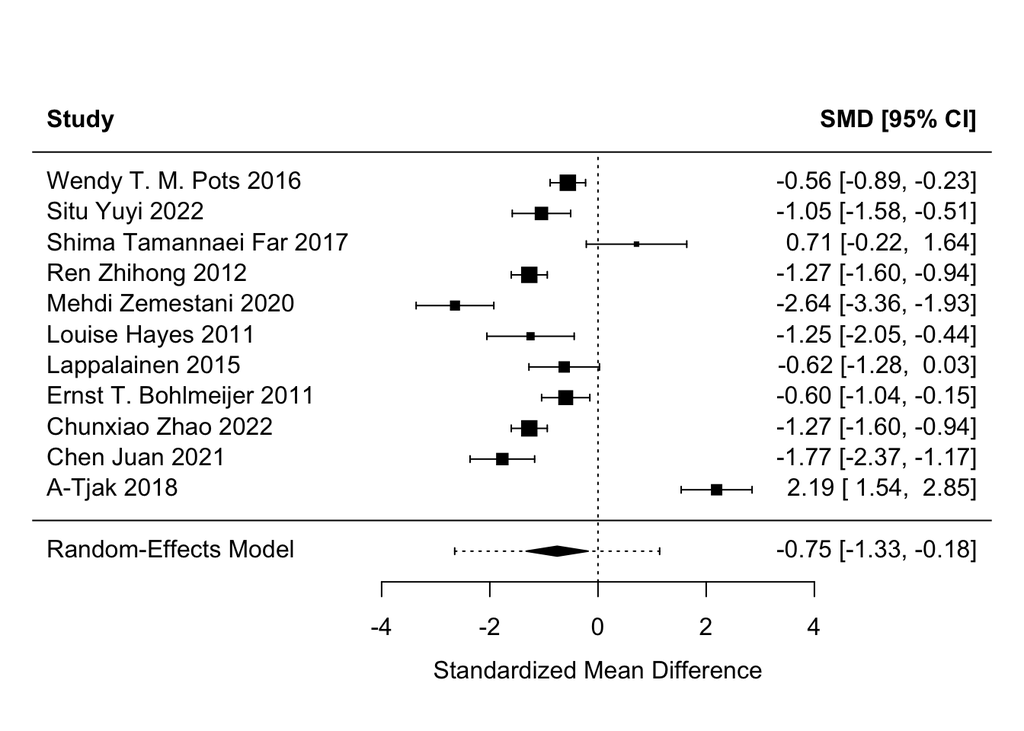

```r
data_zhao <-
  read_xlsx(path = "../../data/raw/data_zhao_forest_plot_1_extracted.xlsx",
            sheet = "original")

data_zhao_all <- data_zhao %>%
  escalc(measure = "SMD",
         m1i = mean_exp,
         m2i = mean_control,
         sd1i = sd_exp,
         sd2i = sd_control,
         n1i = n_exp,
         n2i = n_control,
         data = .)

fit_zhao_all <-
  rma(data = data_zhao_all,
      yi = yi,
      vi = vi,
      slab = study,
      method = "DL") # NB Zhao et al. used the Revman software, which uses a DerSimonian-Laird estimator by default. I therefore use it here in all models.

forest(fit_zhao_all, addpred = TRUE)
```

```r
fit_zhao_all
```

```
##
## Random-Effects Model (k = 11; tau^2 estimator: DL)
##
## tau^2 (estimated amount of total heterogeneity): 0.8485 (SE = 0.4826)
## tau (square root of estimated tau^2 value):      0.9212
## I^2 (total heterogeneity / total variability):   93.11%
## H^2 (total variability / sampling variability):  14.51
##
## Test for Heterogeneity:
## Q(df = 10) = 145.0800, p-val < .0001
##
## Model Results:
##
## estimate      se     zval    pval    ci.lb    ci.ub
##  -0.7548  0.2925  -2.5809  0.0099  -1.3280  -0.1816  **
##
## ---
## Signif. codes:  0 '***' 0.001 '**' 0.01 '*' 0.05 '.' 0.1 ' ' 1
```

Heterogeneity: Q(df = 10) = 145.08, p < .0001, tau^2 = 0.8485, I^2 = 93.1%, H^2 = 14.51

## Outlier/undue influence tests

No specific justification was given in Zhao et al. (2023) for their exclusion of A-Tjak et al. (2018). In the absence of this, I employ {metafor}’s `influence()` function which applies multiple different metrics of undue influence.

```r
influence_zhao <- influence(fit_zhao_all, digits = 2)

influence_zhao
```

```
##
##                          rstudent dffits cook.d cov.r tau2.del QE.del  hat
## Wendy T. M. Pots 2016        0.20   0.06   0.00  1.34     1.04 140.42 0.10
## Situ Yuyi 2022              -0.30  -0.10   0.01  1.20     0.94 144.70 0.09
## Shima Tamannaei Far 2017     1.51   0.44   0.19  1.04     0.81 133.49 0.08
## Ren Zhihong 2012            -0.53  -0.18   0.04  1.31     1.02 138.61 0.10
## Mehdi Zemestani 2020        -2.11  -0.64   0.37  0.97     0.74 120.95 0.09
## Louise Hayes 2011           -0.50  -0.15   0.02  1.14     0.89 144.26 0.08
## Lappalainen 2015             0.13   0.04   0.00  1.17     0.91 144.45 0.09
## Ernst T. Bohlmeijer 2011     0.16   0.05   0.00  1.24     0.97 143.33 0.10
## Chunxiao Zhao 2022          -0.53  -0.18   0.04  1.31     1.02 138.61 0.10
## Chen Juan 2021              -1.09  -0.34   0.12  1.12     0.86 136.07 0.09
## A-Tjak 2018                  4.74   1.52   1.03  0.47     0.32  56.20 0.09
##                          weight  dfbs inf
## Wendy T. M. Pots 2016      9.76  0.06
## Situ Yuyi 2022             9.25 -0.10
## Shima Tamannaei Far 2017   7.97  0.44
## Ren Zhihong 2012           9.75 -0.18
## Mehdi Zemestani 2020       8.70 -0.64
## Louise Hayes 2011          8.40 -0.15
## Lappalainen 2015           8.92  0.04
## Ernst T. Bohlmeijer 2011   9.50  0.05
## Chunxiao Zhao 2022         9.75 -0.18
## Chen Juan 2021             9.09 -0.34
## A-Tjak 2018                8.91  1.55   *
```

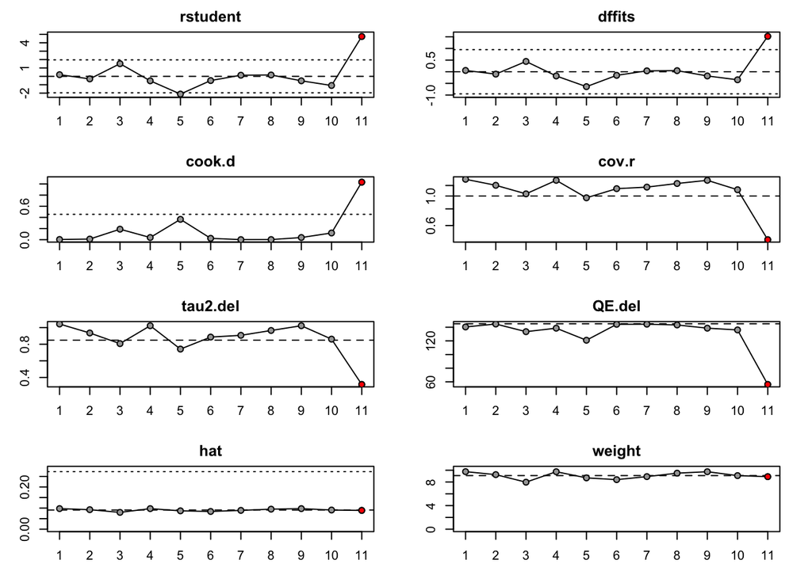

```r
plot(influence_zhao)
```

A-Tjak was detected as an outlier. Although Zhao et al.’s (2023) specific method of outlier detection is unknown, their conclusion is replicate by these results.

## Sensitivity analysis: Exclude Tjak et al. (2018)

As in Zhao Figure 4, and following the results of the above outlier tests, I exclude A-Tjak et al. (2018) and fit a new meta-analysis in order to attempt to reproduce the results reported in Figure 4.

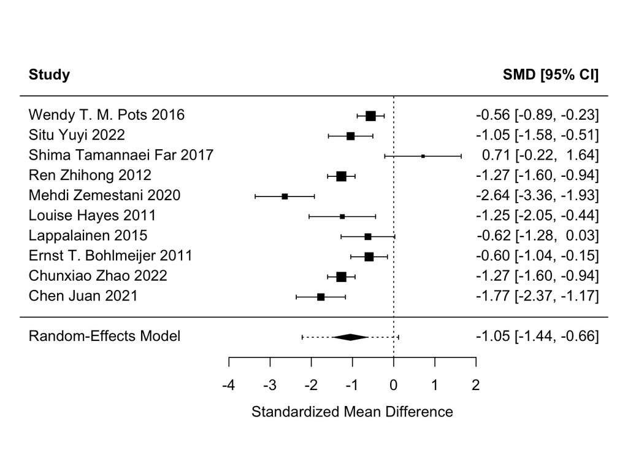

```r
data_zhao_excl_atjak <- data_zhao_all %>%
  filter(study != "A-Tjak 2018")

fit_zhao_excl_atjak <-
  rma(data = data_zhao_excl_atjak,
      yi = yi,
      vi = vi,
      slab = study,
      method = "DL")

forest(fit_zhao_excl_atjak, addpred = TRUE)
```

```r
fit_zhao_excl_atjak
```

```
##
## Random-Effects Model (k = 10; tau^2 estimator: DL)
##
## tau^2 (estimated amount of total heterogeneity): 0.3159 (SE = 0.2036)
## tau (square root of estimated tau^2 value):      0.5621
## I^2 (total heterogeneity / total variability):   83.99%
## H^2 (total variability / sampling variability):  6.24
##
## Test for Heterogeneity:
## Q(df = 9) = 56.2016, p-val < .0001
##
## Model Results:
##
## estimate      se     zval    pval    ci.lb    ci.ub
##  -1.0520  0.2004  -5.2504  <.0001  -1.4447  -0.6593  ***
##
## ---
## Signif. codes:  0 '***' 0.001 '**' 0.01 '*' 0.05 '.' 0.1 ' ' 1
```

Zhao et al.’s (2023) forest plot in Figure 4 reported: Meta-analytic d = -1.05, 95% CI [-1.44, -0.66]. The results above therefore reproduce this result from the summary statistics reported in that forest plot.

Heterogeneity: Q(df = 9) = 56.2, p < .0001, tau^2 = 0.3159, I^2 = 84%, H^2 = 6.24

### NNT

NNT = 1.84, 95% CI [1.44, 2.79]

# Re-extracted

Although the results reported in Figure 4 can be reproduced from the summary statistics reported in Figure 4, the validity of those results are reliant on the summary statistics being accurately extracted from the original studies. Recent work has shown that this is frequently not the case (e.g., Maassen et al., 2020). I therefore attempted to extract the Mean, SD, and N for the ACT and control conditions at the post-intervention time point for each of the original studies.

In the below plots, I use the same labelling as in Zhao et al. (2023). The references (including DOIs) for the studies they refer to are available in the excel files that the data is loaded from. Note that there is imperfect correspondence between Zhao’s labels and the authors of the original studies.

## Comparisons of extracted summary stats

```r
data_reextracted <-
  read_xlsx(path = "../../data/raw/data_zhao_forest_plot_1_extracted.xlsx",
            sheet = "reextracted")

# table
comparisons <-
  bind_rows(
    data_zhao |>
      select(study, mean_exp, sd_exp, n_exp, mean_control, sd_control, n_control) |>
      mutate(source = "Zhao et al. (2023)") |>
      relocate(source, .after = study),
    data_reextracted |>
      select(study, mean_exp, sd_exp, n_exp, mean_control, sd_control, n_control, reextracted) |>
      mutate(sd_exp = janitor::round_half_up(sd_exp, 2),
             sd_control = janitor::round_half_up(sd_control, 2),
             source = "Reextracted") |>
      relocate(source, .after = study)
  ) |>
  arrange(study, desc(source)) |>
  mutate(comparison = case_when(source == "Zhao et al. (2023)" ~ "",
                                reextracted == FALSE ~ "Indeterminable",
                                mean_exp != lag(mean_exp) |
                                  mean_control != lag(mean_control) |
                                  sd_exp != lag(sd_exp) |
                                  sd_control != lag(sd_control) |
                                  n_exp != lag(n_exp) |
                                  n_control != lag(n_control) ~ "Inconsistent",
                                TRUE ~ "Consistent")) |>
  mutate(comparison = case_when((study == "Ren Zhihong 2012" & source == "Reextracted") ~ "Duplicate",
                                TRUE ~ comparison))

# summary table
comparisons |>
  filter(comparison != "") |>
  dplyr::count(comparison) |>
  kable() |>
  kable_classic(full_width = FALSE)
```

| comparison | n |
| --- | --- |
| Consistent | 6 |
| Duplicate | 1 |
| Inconsistent | 2 |
| Indeterminable | 2 |

Two articles with DOIs were only available in Chinese for a fee, and were therefore not accessed. One article did not have a DOI listed and could not be found via internet searches. It is possible that the reference listed in Zhao et al. (2023) is an English translation of the original Chinese title. As such, the reproducibility of 3 of the 11 studies was indeterminable.

```r
# full table
comparisons |>
  kable() |>
  kable_classic(full_width = FALSE)
```

| study | source | mean_exp | sd_exp | n_exp | mean_control | sd_control | n_control | reextracted | comparison |
| --- | --- | --- | --- | --- | --- | --- | --- | --- | --- |
| A-Tjak 2018 | Zhao et al. (2023) | 11.08 | 1.36 | 33 | 7.91 | 1.51 | 25 | NA |  |
| A-Tjak 2018 | Reextracted | 11.08 | 7.81 | 33 | 7.91 | 7.55 | 25 | TRUE | Inconsistent |
| Chen Juan 2021 | Zhao et al. (2023) | 49.36 | 2.18 | 30 | 54.36 | 3.29 | 30 | NA |  |
| Chen Juan 2021 | Reextracted | 49.36 | 2.18 | 30 | 54.36 | 3.29 | 30 | FALSE | Indeterminable |
| Chunxiao Zhao 2022 | Zhao et al. (2023) | 13.61 | 9.48 | 92 | 26.05 | 10.06 | 76 | NA |  |
| Chunxiao Zhao 2022 | Reextracted | 13.61 | 9.48 | 92 | 26.05 | 10.06 | 76 | TRUE | Consistent |
| Ernst T. Bohlmeijer 2011 | Zhao et al. (2023) | 15.94 | 10.37 | 39 | 22.07 | 9.99 | 42 | NA |  |
| Ernst T. Bohlmeijer 2011 | Reextracted | 15.94 | 10.37 | 39 | 22.07 | 9.99 | 42 | TRUE | Consistent |
| Lappalainen 2015 | Zhao et al. (2023) | 13.34 | 6.75 | 18 | 17.85 | 7.34 | 20 | NA |  |
| Lappalainen 2015 | Reextracted | 13.34 | 6.75 | 18 | 17.85 | 7.34 | 20 | TRUE | Consistent |
| Louise Hayes 2011 | Zhao et al. (2023) | 66.05 | 3.24 | 19 | 70.68 | 4.20 | 11 | NA |  |
| Louise Hayes 2011 | Reextracted | 66.05 | 14.12 | 19 | 70.68 | 13.93 | 11 | TRUE | Inconsistent |
| Mehdi Zemestani 2020 | Zhao et al. (2023) | 20.70 | 3.40 | 26 | 32.57 | 5.15 | 30 | NA |  |
| Mehdi Zemestani 2020 | Reextracted | 20.70 | 3.40 | 26 | 32.57 | 5.15 | 30 | TRUE | Consistent |
| Ren Zhihong 2012 | Zhao et al. (2023) | 13.61 | 9.48 | 92 | 26.05 | 10.06 | 76 | NA |  |
| Ren Zhihong 2012 | Reextracted | 13.61 | 9.48 | 92 | 26.05 | 10.06 | 76 | FALSE | Duplicate |
| Shima Tamannaei Far 2017 | Zhao et al. (2023) | 28.20 | 16.28 | 10 | 18.54 | 7.65 | 9 | NA |  |
| Shima Tamannaei Far 2017 | Reextracted | 28.20 | 16.28 | 10 | 18.54 | 7.65 | 9 | TRUE | Consistent |
| Situ Yuyi 2022 | Zhao et al. (2023) | 12.51 | 3.26 | 30 | 15.52 | 2.35 | 30 | NA |  |
| Situ Yuyi 2022 | Reextracted | 12.51 | 3.26 | 30 | 15.52 | 2.35 | 30 | FALSE | Indeterminable |
| Wendy T. M. Pots 2016 | Zhao et al. (2023) | 14.68 | 8.05 | 71 | 19.34 | 8.55 | 78 | NA |  |
| Wendy T. M. Pots 2016 | Reextracted | 14.68 | 8.05 | 71 | 19.34 | 8.55 | 78 | TRUE | Consistent |

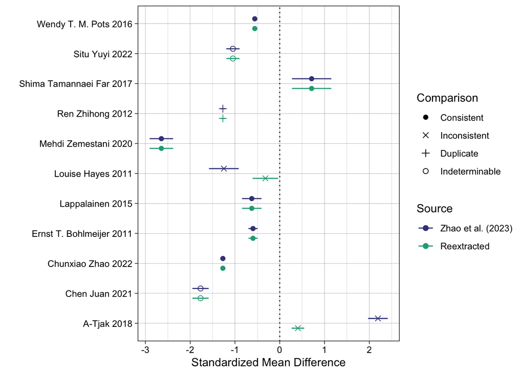

```r
# plot
compared_es <- comparisons %>%
  escalc(measure = "SMD",
         m1i = mean_exp,
         m2i = mean_control,
         sd1i = sd_exp,
         sd2i = sd_control,
         n1i = n_exp,
         n2i = n_control,
         data = .) |>
  mutate(Comparison = ifelse(comparison == "", lead(comparison), comparison),
         Comparison = fct_relevel(Comparison, "Consistent", "Inconsistent", "Duplicate", "Indeterminable")) |>
  rename(Source = source)

ggplot(compared_es, aes(yi, study, color = Source, shape = Comparison)) +
  geom_vline(xintercept = 0, linetype = "dotted") +
  geom_linerangeh(aes(xmin = yi - vi*1.96, xmax = yi + vi*1.96), position = position_dodge(width = 0.65)) +
  geom_point(position = position_dodge(width = 0.65), size = 2) +
  theme_linedraw() +
  scale_color_viridis_d(begin = 0.2, end = 0.6, direction = -1,
                     guide = guide_legend(reverse = TRUE)) +
  scale_shape_manual(values = c("Consistent" = 16, "Indeterminable" = 1, "Inconsistent" = 4, "Duplicate" = 3)) +
  ylab("") +
  xlab("Standardized Mean Difference")
```

```r
ggsave(filename = "verification_zhao_2023_comparisons_plot.pdf",
       path = "../../communciations/plots/",
       create.dir = TRUE,
       width = 7,
       height = 4.5)

ggsave(filename = "verification_zhao_2023_comparisons_plot.png",
       path = "../../communciations/plots/",
       create.dir = TRUE,
       dpi = 600,
       width = 7,
       height = 4.5)


# compared_es |>
#   mutate(yi = ifelse(Comparison != "Inconsistent" & Source == "Reextracted", NA, yi),
#          vi = ifelse(Comparison != "Inconsistent" & Source == "Reextracted", NA, vi)) |>
#   ggplot(aes(yi, study, color = Source, shape = Comparison)) +
#   geom_vline(xintercept = 0, linetype = "dotted") +
#   geom_linerangeh(aes(xmin = yi - vi*1.96, xmax = yi + vi*1.96), position = position_dodge(width = 0.65)) +
#   geom_point(position = position_dodge(width = 0.65), size = 2) +
#   theme_linedraw() +
#   scale_color_viridis_d(begin = 0.2, end = 0.6, direction = -1,
#                      guide = guide_legend(reverse = TRUE)) +
#   scale_shape_manual(values = c("Consistent" = 16, "Indeterminable" = 1, "Inconsistent" = 4)) +
#   ylab("") +
#   xlab("Standardized Mean Difference")
```

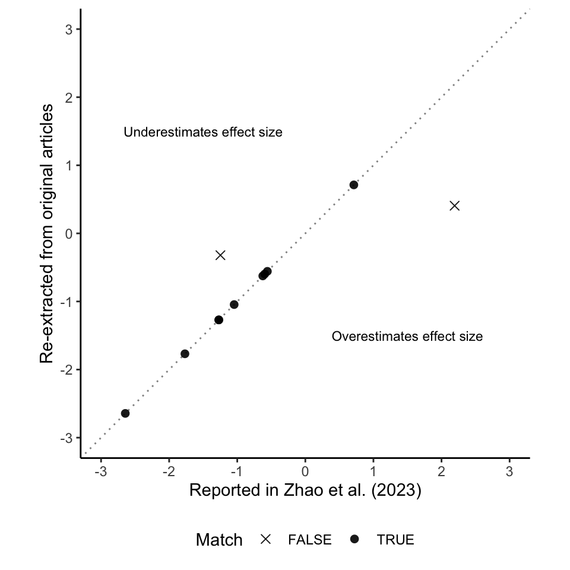

```r
# library(wesanderson)
# library(RColorBrewer)

compared_es |>
  select(study, Source, yi) |>
  pivot_wider(names_from = Source,
              values_from = yi) |>
  rename(zhao = "Zhao et al. (2023)",
         reextracted = Reextracted) |>
  mutate(Match = zhao == reextracted) |>
  ggplot(aes(zhao, reextracted, shape = Match)) +
  geom_abline(slope = 1, linetype = "dotted", alpha = 0.5) +
  geom_point(size = 2.25, alpha = 0.9) +
  theme_classic() +
  #scale_color_viridis_d(begin = 0.3, end = 0.6, option = "mako") +
  scale_shape_manual(values = c(4, 16)) +
  #scale_color_manual(values = wes_palette(n = 2, name = "Royal1")) +
  #scale_color_brewer(palette = "Dark2") +
  scale_x_continuous(breaks = scales::breaks_pretty(),
                     limit = c(-3, 3),
                     name = "Reported in Zhao et al. (2023)") +
  scale_y_continuous(breaks = scales::breaks_pretty(),
                     limit = c(-3, 3),
                     name = "Re-extracted from original articles") +
  theme(legend.position = "bottom") +
  #legend.box.background = element_rect(colour = "black")) +
  annotate("text", x = 1.5, y = -1.5, size = 3, label = "Overestimates effect size") +
  annotate("text", x = -1.5, y = 1.5, size = 3, label = "Underestimates effect size") +
  coord_fixed(ratio = 1)
```

```r
ggsave(filename = "verification_zhao_2023_comparisons_plot_alt.pdf",
       path = "../../communciations/plots/",
       create.dir = TRUE,
       width = 5,
       height = 4.5)

ggsave(filename = "verification_zhao_2023_comparisons_plot_alt.png",
       path = "../../communciations/plots/",
       create.dir = TRUE,
       dpi = 600,
       width = 5,
       height = 4.5)
```

## Updated meta-analysis of the 10 studies after excluding the duplicate

Following the same workflow as Zhao et al. (2023), a random effects meta-analysis was then fit to the 10 sets of effect sizes (i.e., including the 3 that were indeterminable, on the liberal assumption that they are correct, but excluding the duplicate on the reasonable assumption that it is not).

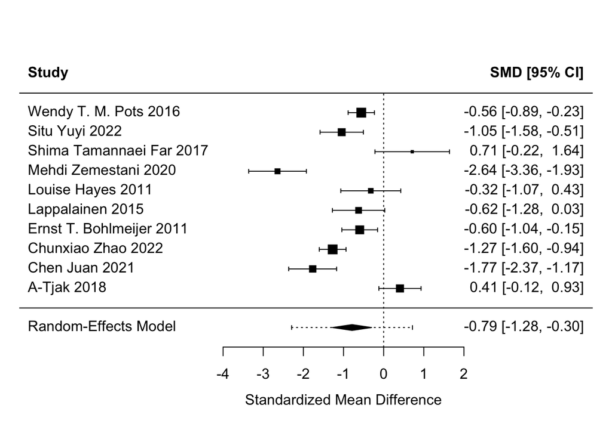

```r
data_reextracted_excluded <- data_reextracted %>%
  filter(study != "Ren Zhihong 2012") %>%
  escalc(measure = "SMD",
         m1i = mean_exp,
         m2i = mean_control,
         sd1i = sd_exp,
         sd2i = sd_control,
         n1i = n_exp,
         n2i = n_control,
         data = .)

fit_reextracted <-
  rma(data = data_reextracted_excluded,
      yi = yi,
      vi = vi,
      slab = study,
      method = "DL")

forest(fit_reextracted, addpred = TRUE)
```

```r
fit_reextracted
```

```
##
## Random-Effects Model (k = 10; tau^2 estimator: DL)
##
## tau^2 (estimated amount of total heterogeneity): 0.5280 (SE = 0.3223)
## tau (square root of estimated tau^2 value):      0.7267
## I^2 (total heterogeneity / total variability):   88.62%
## H^2 (total variability / sampling variability):  8.79
##
## Test for Heterogeneity:
## Q(df = 9) = 79.1103, p-val < .0001
##
## Model Results:
##
## estimate      se     zval    pval    ci.lb    ci.ub
##  -0.7878  0.2489  -3.1651  0.0016  -1.2756  -0.2999  **
##
## ---
## Signif. codes:  0 '***' 0.001 '**' 0.01 '*' 0.05 '.' 0.1 ' ' 1
```

Heterogeneity: Q(df = 9) = 79.11, p < .0001, tau^2 = 0.528, I^2 = 88.6%, H^2 = 8.79

## Outlier/undue influence tests

Similarly, I then checked for outliers/undue influence.

```r
influence_reextracted <- influence(fit_reextracted, digits = 2)

influence_reextracted
```

```
##
##                          rstudent dffits cook.d cov.r tau2.del QE.del  hat
## Wendy T. M. Pots 2016        0.29   0.09   0.01  1.39     0.67  75.97 0.11
## Situ Yuyi 2022              -0.33  -0.12   0.02  1.23     0.59  78.36 0.10
## Shima Tamannaei Far 2017     1.88   0.56   0.29  0.99     0.47  68.38 0.08
## Mehdi Zemestani 2020        -2.76  -0.84   0.53  0.80     0.36  53.00 0.09
## Louise Hayes 2011            0.59   0.19   0.04  1.15     0.55  77.33 0.09
## Lappalainen 2015             0.21   0.06   0.00  1.19     0.58  78.75 0.10
## Ernst T. Bohlmeijer 2011     0.24   0.08   0.01  1.29     0.62  78.03 0.11
## Chunxiao Zhao 2022          -0.64  -0.23   0.06  1.27     0.61  69.94 0.11
## Chen Juan 2021              -1.34  -0.44   0.19  1.06     0.50  68.63 0.10
## A-Tjak 2018                  1.82   0.64   0.32  0.90     0.41  56.19 0.10
##                          weight  dfbs inf
## Wendy T. M. Pots 2016     11.14  0.09
## Situ Yuyi 2022            10.26 -0.12
## Shima Tamannaei Far 2017   8.23  0.56
## Mehdi Zemestani 2020       9.35 -0.85   *
## Louise Hayes 2011          9.20  0.18
## Lappalainen 2015           9.70  0.06
## Ernst T. Bohlmeijer 2011  10.69  0.08
## Chunxiao Zhao 2022        11.12 -0.23
## Chen Juan 2021             9.98 -0.44
## A-Tjak 2018               10.33  0.63
```

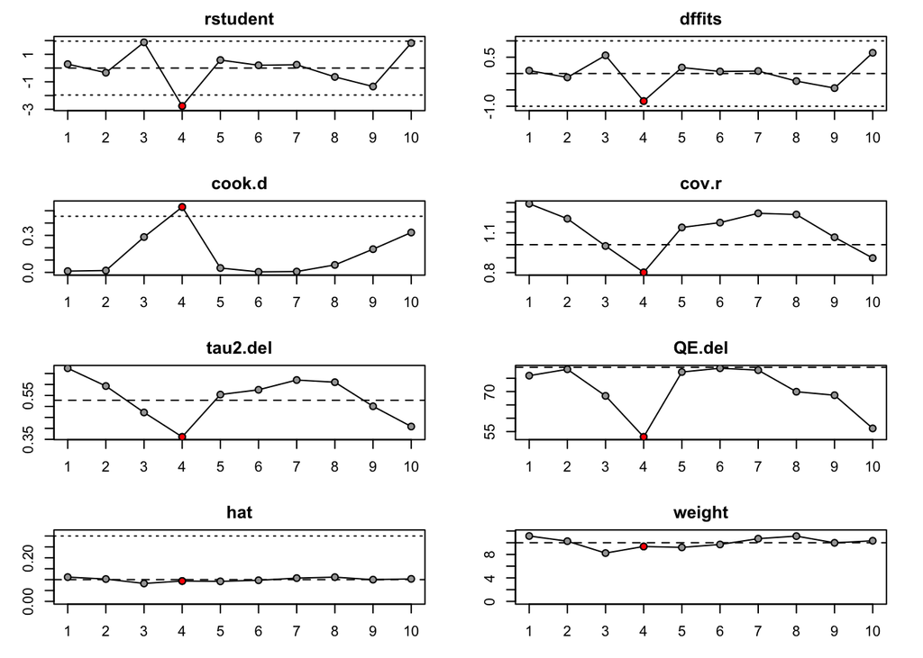

```r
plot(influence_reextracted)
```

This suggests that Zemestani et al. (2020) is an outlier that should be excluded, whereas Zhao et al. (2023) excluded A-Tjak et al. (2018).

Note that there are additional reasons to exclude the results of Zemestani et al. (2020): as documented in [this pubpeer comment](https://pubpeer.com/publications/0E13E34679B18385D6C4C29143A9CD), several results reported in that article fail StatCheck, GRIM, and GRIMMER tests (i.e., the reported results are mathmatically impossible); the reported SD of the BDI-II scores is implausibly small given normative data for the BDI-II elsewhere, and as a result the SMD effect size is implausibly large (d = -2.64 in Zhao et al. 2023).

## Sensitivity analysis: Exclude Zemestani et al. (2020)

I therefore fitted a new meta-analysis to the remaining 9 studies after excluding Zemestani et al. (2020).

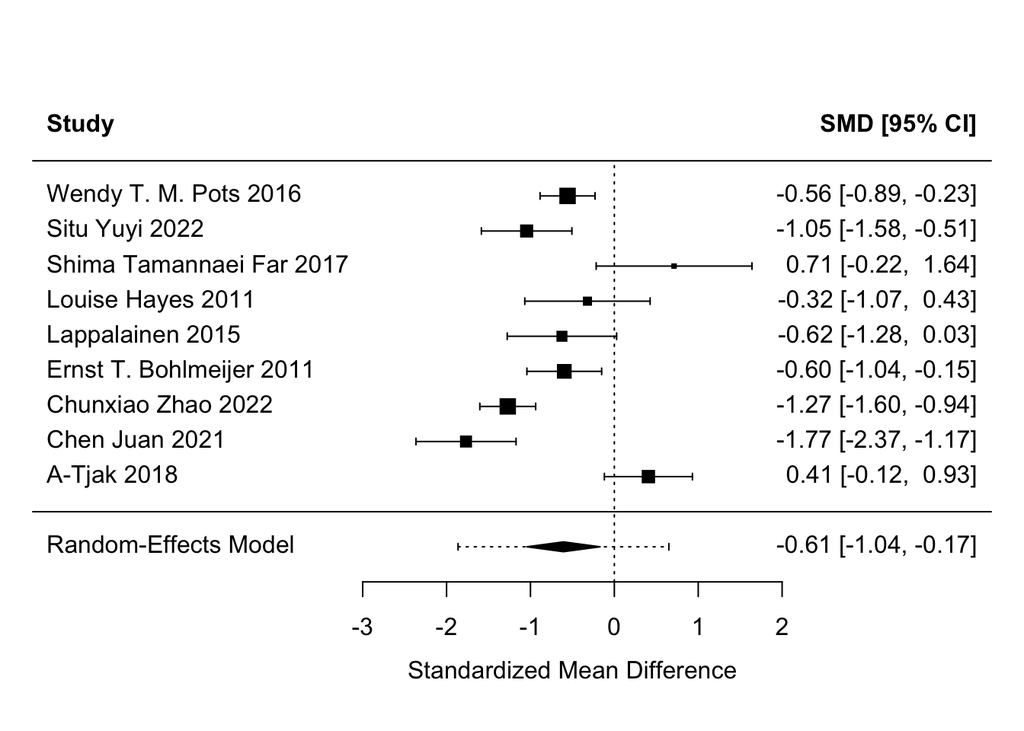

```r
data_reextracted_excluded_zemestani <- data_reextracted_excluded |>
  filter(study != "Mehdi Zemestani 2020")

fit_reextracted_excl_zemestani <-
  rma(data = data_reextracted_excluded_zemestani,
      yi = yi,
      vi = vi,
      slab = study,
      method = "DL")

forest(fit_reextracted_excl_zemestani, addpred = TRUE)
```

```r
fit_reextracted_excl_zemestani
```

```
##
## Random-Effects Model (k = 9; tau^2 estimator: DL)
##
## tau^2 (estimated amount of total heterogeneity): 0.3613 (SE = 0.2398)
## tau (square root of estimated tau^2 value):      0.6011
## I^2 (total heterogeneity / total variability):   84.90%
## H^2 (total variability / sampling variability):  6.62
##
## Test for Heterogeneity:
## Q(df = 8) = 52.9976, p-val < .0001
##
## Model Results:
##
## estimate      se     zval    pval    ci.lb    ci.ub
##  -0.6065  0.2227  -2.7230  0.0065  -1.0431  -0.1700  **
##
## ---
## Signif. codes:  0 '***' 0.001 '**' 0.01 '*' 0.05 '.' 0.1 ' ' 1
```

```r
percent_change_in_ES <- round_with_zeros(as.numeric((fit_reextracted_excl_zemestani$b/fit_zhao_excl_atjak$b *100)) - 100)
```

A significant meta-analytic effect was still found, but this effect was -42.3% smaller than that reported by Zhao et al. (2023) after correcting the data extraction errors and refitting the meta-analysis and sensitivity analysis workflow.

Heterogeneity: Q(df = 8) = 53, p < .0001, tau^2 = 0.3613, I^2 = 84.9%, H^2 = 6.62

### NNT

NNT = 3.01, 95% CI [1.85, 10.45]

## Bias correction via Robust Bayesian Meta-Analysis

Zhao et al. (2023) employ a sensitivity analysis to remove outlier studies (but not studies flagged in the risk of bias assessment), but they do not employ any bias correction method to correct for sources such as publication bias. Here I use Robust Bayesian Meta-Analysis (RoBMA), an ensemble method of correcting for potential sources of bias.

```r
library(RoBMA)

set.seed(42)

# Bayesian selection model
roBMA_model <- RoBMA(d = data_reextracted_excluded_zemestani$yi,
                     se = sqrt(data_reextracted_excluded_zemestani$vi),
                     effect_direction = "negative",
                     prior_scale = "cohens_d",
                     study_names = data_reextracted_excluded_zemestani$study,
                     parallel = TRUE)


# summary(roBMA_model)

interpret(roBMA_model)
```

```
## [1] "Robust Bayesian meta-analysis found weak evidence in favor of the effect, BF_10 = 1.50, with mean model-averaged estimate Cohen's d = -0.290, 95% CI [-0.899,  0.072]. Robust Bayesian meta-analysis found strong evidence in favor of the heterogeneity, BF^rf = 143925.45, with mean model-average…
```

Results from the RoBMA suggest that the true effect size may be a) smaller again and b) not detectably different from zero.

# Preemptive response

To preempt one possible response to these concerns: readers might argue something along the lines of “the conclusions of Zhao et al. (2023) are not substantially affected by the correction of these errors, and therefore there is no strong need for concern.” However, any such reactions should be seen as worrisome rather than encouraging: meta-analyses are often argued to be at the top of the Evidence Pyramid, and their goal is to precisely estimate the true effect size beyond merely estimating whether the true effect size is non-zero or not. To retreat to the weaker position that the obtained effect size does not substantively matter is to undermine the point of doing the meta-analysis in the first place. Either the empirical estimates matter or they don’t.

Finally, as discussed at the start of this document, no attempt was made to reproduce or attempt to understand the impact of the detected extraction errors on the other analyses reported in Zhao et al. (2023). It is likely that the subgroup analyses reported after Figure 4 will also be affected by the issues detected above. It is also possible that other issues exist, given that errors were made at the relatively simple data extraction phase. The results and conclusions of Zhao et al. (2023) should therefore be regarded with great skepticism given the issues already detected, and require careful revision throughout to ensure no other errors were made.

Equally, this verification does not attempt to critique things that were not done by Zhao et al. (2023). For example, the authors do not apply any method of bias correction for p-hacking or publication bias, and instead take the reported results at face value. Applying such tests typically shrinks the observed estimate. Equally, although the authors did include a risk of bias assessment, the results of that assessment were not employed in any sensitivity analysis (e.g., using bias scores as weights or as a method of exclusion).